# GR5072 Modern Data Structures_HW 6

Bolim Son

October 25, 2019

```r
# Load packages
library(stringr)
library(dplyr)
```

### **1. Scrabble**

```r
# Setup, load data
# install.packages("ScrabbleScore")
library(ScrabbleScore)
data(twl06)
scrabble <- twl06
```

**a) Words with `z`**

Select all words that contain at least one z. Among the z-words, tabulate how many z’s the words contain (i.e. how many words contain one z, two z’s etc.).

```r
# Select all words with at least one "z"
z_words <- str_subset(scrabble, "z+")
```

```r
# There are 7124 words with at least one "z"
length(z_words)
```

```
## [1] 7124
```

```r
# Print the first 10 words to check (there are just too many)
z_words[1:10]
```

```
##  [1] "ablaze"        "absolutize"    "absolutized"   "absolutizes"
##  [5] "absolutizing"  "abuzz"         "accessorize"   "accessorized"
##  [9] "accessorizes"  "accessorizing"
```

```r
# Count "z"
z_count <- str_count(scrabble, "z")

# Table with the count of "z" in a word
table(z_count)
```

```
## z_count
##      0      1      2      3      4
## 171567   6677    424     16      7
```

**b) Word lengths**

Provide a histogram of the word lengths in the scrabble dictionary.

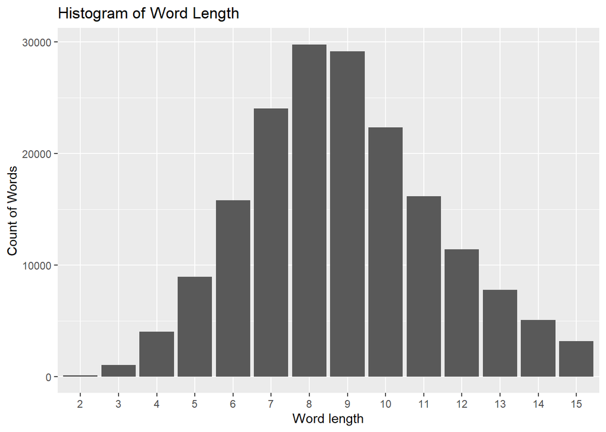

```r
# Get length
word_len <- data.frame(table(str_length(scrabble)))


# Make a histogram
library(ggplot2)
ggplot(data = word_len) +
  geom_col(mapping = aes(x = Var1, y = Freq))+
  labs(title = "Histogram of Word Length", x = "Word length", y = "Count of Words")
```

**c) Vowels**

How many words both start and end with a vowel?

```r
# Use regular expression for vowels
sum(str_count(scrabble, pattern = "^[aeiou].*[aeiou]$"))
```

```
## [1] 5075
```

5075 words start and end with a vowel

**d) Longest word with `New York`**

What is the longest scrabble word that can be formed just out of the letters contained in “New York” (repetitions of letters are allowed)?

```r
# Find ones that only have n,e,w,y,o,r,k
ny_words <- str_subset(scrabble, pattern = "^[newyork]{1,}+$")

# Return longest one
ny_words[str_length(ny_words)==max(str_length(ny_words))]
```

```
## [1] "nonworker"
```

**e) Consonants only**

Find the word(s) with the largest number of consecutive consonants.

```r
# Subset words with 2 or more consecutive consonants
con_words <- str_subset(scrabble, pattern = "^.*[^aeiou]{2,}.*$")

# Create a data.frame with the longest consonants
longest <- as.data.frame(cbind(con_words, #Words
        str_locate(con_words, pattern = "[^aeiou]{2,}"))) %>% # Consonant locations
  mutate(end = as.numeric(levels(end)[end]),
         start = as.numeric(levels(start)[.$start])) %>% # Format numbers as numbers
  mutate(c_length = end - start + 1) %>% # Cacluate length
  arrange(desc(c_length)) %>% # Arragne by length
  filter(c_length == max(c_length)) # Filter the longest ones

# Return
longest
```

| con_words | start | end | c_length |
| --- | --- | --- | --- |
| dysrhythmia | 1 | 9 | 9 |
| dysrhythmias | 1 | 9 | 9 |
| dysrhythmic | 1 | 9 | 9 |
| polyrhythms | 3 | 11 | 9 |
| sulfhydryls | 3 | 11 | 9 |

**f) Bonuzz (optional)**

Find the z-word(s) with z’s that are as far apart as possible (i.e. we are interested in the distance between any two z’s in the word). That means the word could contain more than two z’s.

```r
# Subset words with 2 or more "z"
z_words <- str_subset(scrabble, pattern = ".*[z]..*[z].*")

# double "zz" as "z" (because only the location is necessary)
z_words_2 <- str_replace_all(z_words, "zz", "z")

# Create a data.frame with the z words
z_longest <- as.data.frame(cbind(z_words, #Words
        str_locate(z_words_2, pattern = "[z]{1,}.*[z]{1,}"))) %>% # z locations
  mutate(end = as.numeric(levels(end)[end]),
         start = as.numeric(levels(start)[.$start])) %>% # Format numbers as numbers
  mutate(z_length = end - start - 1) %>% # Cacluate length
  arrange(desc(z_length)) %>% # Arragne by length
  filter(z_length == max(z_length)) # Filter the longest ones

# Return
z_longest
```

| z_words | start | end | z_length |
| --- | --- | --- | --- |
| benzimidazole | 4 | 10 | 5 |
| benzimidazoles | 4 | 10 | 5 |
| razzamatazz | 3 | 9 | 5 |
| razzamatazzes | 3 | 9 | 5 |

### **2. Emergency Hospital Injuries**

```r
# Read file
ehi <- readr::read_csv("emergency.csv", col_names = FALSE)

# Make it to a vector
ehi <- as.vector(unlist(ehi))
ehi <- str_to_lower(ehi)
```

**a) Fractures**

Find all narratives related to “fractures”. Try to include singular/plural/verb forms in your search. How many fracture narratives can you find?

```r
# Extract "fracture" narratives
fractures <- ehi %>%
  str_subset(., pattern = "\\b[Ff]ractur(e|ed|es|ing)")

# Extract distinct narrative forms
fracture_narratives <- fractures %>%
  str_extract_all(., pattern = "\\b[Ff]ractur(.|..|...)\\b")%>%
  unique(.) %>%
  unlist(.) %>%
  as.vector(.) %>%
  unique(.)

# Return
fracture_narratives
```

```
## [1] "fractured"  "fracture"   "fracturing" "fractures"
```

There are 4 fracture narratives, which are “fractured”, “fracture”, “fracturing”, and “fractures”.

**c) Body Parts**

Among the fracture narratives, try to identify the body parts that are fractured (Note: Don’t go overboard. A selection of parts is sufficient. No need to become a medicical doctor here). Make a histogram of fractured body parts (but make sure plural and singular are combined.)

```r
# Extract body parts
body_parts <- "arm(.)|leg(.)|head|skull|hip(.)|finger(.)|ankle(.)|foot|feet|hand|hands"

# Extracted from fracture string
fractures_body <- fractures %>%
  str_extract_all(., pattern = body_parts)

# Select the ones only with body parts, remove redundancies
fractures_body_df <- fractures_body[lapply(fractures_body, length)>0] %>%
  unlist(.) %>%
  str_replace_all(., "[[:punct:]]", "") %>%
  str_replace_all(., "s$", "") %>%
  str_replace_all(., " *", "") %>%
  str_replace_all(., "foot", "feet") %>%
  as.data.frame.character(., stringsAsFactors = FALSE)

# Rename column name
fractures_body_df$body_part <- fractures_body_df$.

# Final result of fractured parts and frequencies
fractures_body_tallied <- fractures_body_df %>%
  select(-".") %>%
  group_by(body_part) %>%
  summarize(totals = n())

# Return result
fractures_body_tallied
```

| body_part | totals |
| --- | --- |
| ankle | 47 |
| arm | 48 |
| feet | 74 |
| finger | 70 |
| hand | 62 |
| head | 12 |
| hip | 32 |
| leg | 19 |
| skull | 3 |

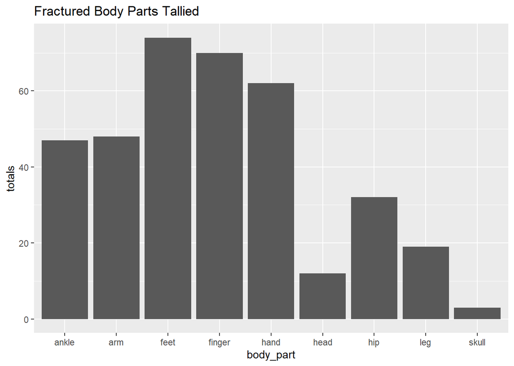

```r
# Visualization
library(ggplot2)
ggplot(data = fractures_body_tallied) +
  geom_col(mapping = aes(x = body_part, y = totals)) +
  labs(title = "Fractured Body Parts Tallied")
```

**d) Age and Gender**

Let’s try to extract age and gender. You are generally looking for a pattern with a number (age), something to indicate the units, e.g. YO or YR for years old, or MO for months old, and a character that identifies the gender. So, I suggest to think of a pattern that combines these three parts.

Create variables for age and gender (make sure to convert months to years when necessary).

How many males and females are in the data? Provide a line graph of the number of injuries (y-axis) vs age (x-axis) disaggregated by gender.

```r
# Extract info for years old
ag_pattern_yr <- "\\b([0-9]{1,}) *(yo|yr) *(m|male|f|female)"
age_gender_yr<- str_extract_all(ehi, pattern = ag_pattern_yr)
age_gender_yr <- age_gender_yr[lapply(age_gender_yr, length)>0]

# Change years info to data frame
yr_df <- age_gender_yr %>%
  str_remove_all(., "\\s") %>%
  str_split(., pattern = "(yo|yr)", simplify = TRUE) %>%
  as.data.frame(., stringsAsFactors = FALSE) %>%
  mutate(V1 = as.numeric(V1)) %>%
  select(-V3) %>%
  filter(!is.na(V2), !is.na(V1), V1 > 0) %>%
  rename(age = V1, gender = V2)
```

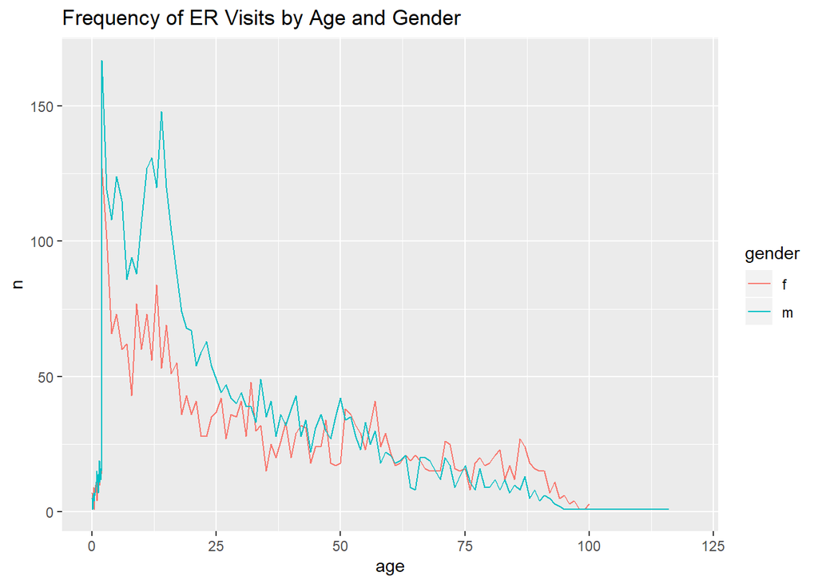

```r
# Extract info for months old
ag_pattern_mo <- "\\b([0-9]{1,}) *(mo) *(m|male|f|female)"
age_gender_mo <- str_extract_all(ehi, pattern = ag_pattern_mo)
age_gender_mo <- age_gender_mo[lapply(age_gender_mo, length)>0]

# Change months to years, change it to a data frame
mo_df <- age_gender_mo %>%
  str_remove_all(., "\\s") %>%
  str_split(., pattern = "(mo)", simplify = TRUE) %>%
  as.data.frame(., stringsAsFactors = FALSE)%>%
  mutate(V1 = round(as.numeric(V1)/12, digits = 2)) %>%
  filter(!is.na(V1), !is.na(V2), V1 > 0) %>%
  rename(age = V1, gender = V2)

# Combine
ag_total <- rbind(yr_df, mo_df)

# Visualization
library(ggplot2)

ag_total %>%
  group_by(age, gender) %>%
  count() %>%
  ggplot() +
  geom_line(mapping = aes(x = age, y = n, color = gender)) +
  xlim(0,120) +
  labs(title = "Frequency of ER Visits by Age and Gender")
```